# **Calibration model (simplified)**

K. Davidson

Updated 2021-08-01

## **Background**

The purpose of this project is to compare paired population estimates derived from low- and high-precision enumeration methods on the same system-years to develop calibration factors. The calibration factors are used to “convert” a low-precision estimate (obtained through visual counts, either aerial or ground-based) to a high-precision estimate. High-precision estimates are obtained through fences, mark-recaptures, or more recently, SONAR programs. A dataset of 160 Fraser River sockeye programs dating back to 1988 has been collated for this project, with some years having ground, aerial and high-precision methods used.

Historically, a series of fences were installed on Early Stuart creeks to determine the original expansion factor. Fence counts were typically 1.8 times higher than visual counts (on average). This factor (1.8) is currently used to expand the majority of population estimates obtained through a visual count. However, this represents conditions in small, stable, clear streams and the 1.8 expansion is not always applicable for larger, flashy, turbid systems. FIA Stock Assessment began a 10-year project around 2008 to expand the calibration dataset to include a broader variety of stream and river types and enumeration methods. This work ended in 2018, and now observations are added opportunistically. Unique system-year indices were calculated for each survey event, where the index is the high-precision estimate (HPE) divided by the low-precision estimate (LPE).

Early work investigated univariate relationships and the range of possible indices, but did not integrate multiple variables in one modelling framework. Here we begin with a basic generalized linear model to begin to examine multivariate relationships to the index. The following is an exercise in model development and does not represent the final model selection. The predictor variables available/of interest are:

- Stability (categorical)
- Water clarity (categorical)
- Substrate shade (categorical)
- LWD (categorical)
- LPE (continuous)
- LPE method (categorical)

These variables were used in a gamma-distributed generalized linear model (GLM) with an inverse link function. LPE was re-scaled (but not centered) based on recommendations from the model output. The model (see below) was fit to a randomly selected 80% (n=128 unique survey-years) of the dataset while 20% (n=32 unique survey-years) was held back for model validation and assessment. Models were fit using the *glm()* function in the base *stats* package, and all model combinations were run using *dredge()* in the *MuMIn* package. Models were ranked using AIC corrected for small sample size (AICc), and the top model (dAICc = 0) and the top model set (dAIC < 4) were extracted using the *MuMIn* package. As we are interested in the model with the best predictive power (rather than ecological explanatory power), we evaluated the predictive power of both the top model and the set of top models (dAIC < 4). Expansion factors, or ‘indices’, (and subsequent population estimates) were predicted for the test dataset using the top model and model-averaged predictions from the set of top models (dAIC < 4). These two types of predictions were compared to the historically-used 1.8 expansion factor and the known population estimate to assess whether the model out-performed the historical method, and provided reasonable population estimates (Figure 3).

## **Preliminary results**

#### **Data exploration: Multicollinearity and variable relationships**

In the initial global model, VIF scores were high for stream size (VIF>3; Table 1) and stream size exhibited a strong positive relationship with stream stability (r=0.72), a strong negative relationship with large woody debris (‘lwd’, r=-0.71), and moderate relationship with LPE method (r=0.61; Figure 1). Removal of ‘size_recode’ resulted in reasonable correlation values for the remaining variables (VIF<3 and r<0.6, results not shown).

*Table 1. Variance Inflation Factor (VIF) scores for the global model. All VIF scores were <3 once ‘size_recode’ was removed.*

| Variable | value |
| --- | --- |
| system_stability | 3.704115 |
| size_recode | 8.128730 |
| water_clarity_recode | 1.675301 |
| substrate_shade_recode | 1.204284 |
| lwd_recode | 3.046364 |
| lpe | 1.378565 |
| lpe_method | 1.985008 |

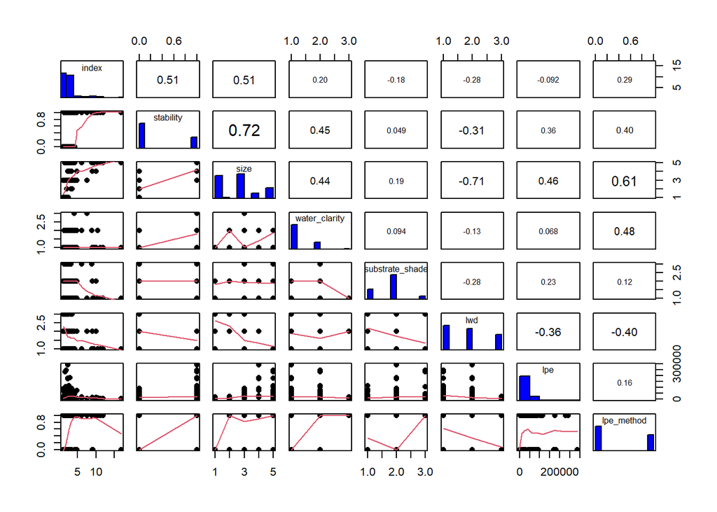

*Fig. 1. Pairs plot for variables indicating level of collinearity between each variable pairing. Histograms of data observations given on the diagonal. Smoothed lines (red) generated using default loess smoother. No data transformations. Ordinal categorical variables re-coded as integers for purposes of plotting.*

There is evidence of linear relationships between the index and most variables (Figure 2). Smoothed non-linear relationships are shown just for reference and for future considerations with GAM use, but are not considered in this GLM exercise as sample sizes are too limited. The relationships suggest GLM is acceptable for use given the current data limitations.

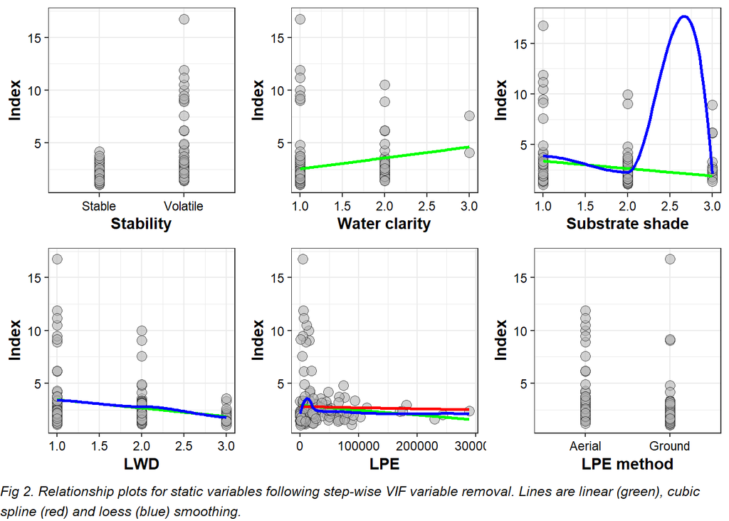

#### **Model development**

The following model was fit to 128 surveys, while 32 surveys were held back for validation. Top models (dAICc < 4) are shown in Table 2. The top model contained terms for large woody debris, LPE, system stability and water clarity and accounted for 34% of model weights.

```r
Model formula:
m.global <- glm(index ~ system_stability + large_woody_debris + water_clarity + substrate_shade + lpe_sc + lpe_method, data=cal.80,  family=Gamma(link="inverse"), na.action = "na.fail")
```

*Table 2. Set of top models with dAICc (“delta”) < 4.*

| Model | (Intercept) | large_woody_debris | lpe_sc | system_stability | water_clarity | lpe_method | substrate_shade | df | logLik | AICc | delta | weight |
| --- | --- | --- | --- | --- | --- | --- | --- | --- | --- | --- | --- | --- |
| 54 | 0.5455502 | + | 0.1069312 | + | + | NA | NA | 8 | -166.7826 | 350.7754 | 0.0000000 | 0.33925478 |
| 56 | 0.5201523 | + | 0.1066947 | + | + | + | NA | 9 | -166.1231 | 351.7715 | 0.9961543 | 0.20616446 |
| 62 | 0.5341022 | + | 0.0940909 | + | + | NA | + | 10 | -165.3128 | 352.5060 | 1.7305894 | 0.14280166 |
| 30 | 0.6075388 | + | 0.1013027 | + | NA | NA | + | 8 | -167.7163 | 352.6427 | 1.8672973 | 0.13336673 |
| 64 | 0.5185697 | + | 0.0951900 | + | + | + | + | 11 | -164.8779 | 354.0316 | 3.2562271 | 0.06659556 |
| 22 | 0.5507388 | + | 0.1145285 | + | NA | NA | NA | 6 | -170.8413 | 354.3767 | 3.6013432 | 0.05604079 |
| 32 | 0.5980604 | + | 0.1028849 | + | NA | + | + | 9 | -167.4304 | 354.3862 | 3.6108147 | 0.05577602 |

The model-averaged set of top models indicated that large woody debris, LPE and system stability all had the highest importance, with substrate shade and the LPE method having minimal importance (Table 3).

*Table 3. Relative variable importance of variables included in the model-averaged set of top models (dAICc < 4).*

| Variable name | Relative importance |
| --- | --- |
| large_woody_debris | 1.0000000 |
| lpe_sc | 1.0000000 |
| system_stability | 1.0000000 |
| water_clarity | 0.7548165 |
| substrate_shade | 0.3985400 |
| lpe_method | 0.3285360 |

**Model validation**

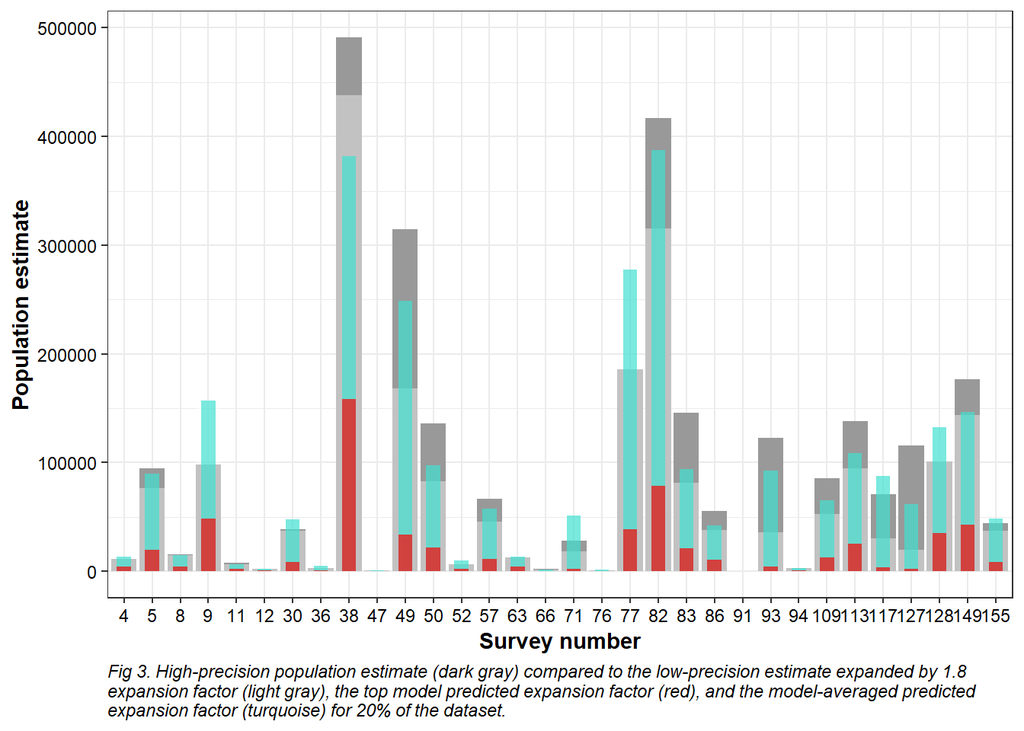

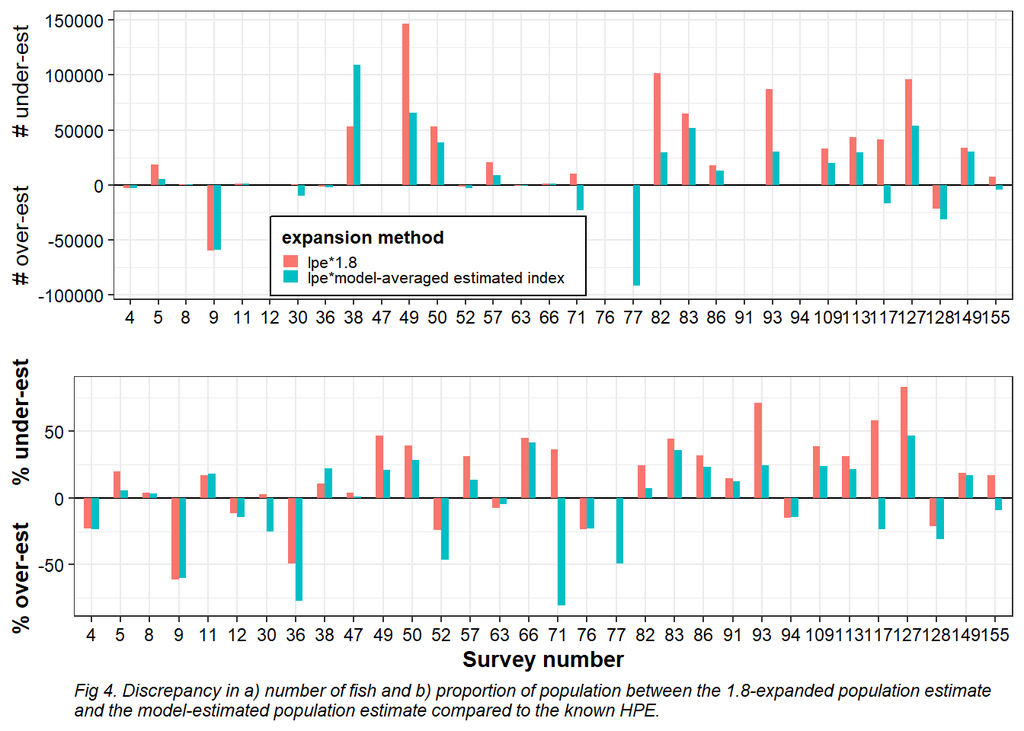

#### **Future directions**

The next steps in this work are to determine how the model changes when the Harrison River is removed. The Harrison is a unique case of a relatively new high-precision program, an often unpredictable spawner population, and difficult counting conditions, and has only recently been added to the database. It is often an outlier in data exploration stages, and it may benefit from its own unique calibration assessment (and likewise the model fit to the entire dataset may also improve).

A retrospective examination of population size changes using this model will also be conducted on systems typically assessed using low-precision, e.g., Early Stuart, N/S Thompson tribs, or some non-dominant years (e.g., Quesnel or Chilliwack).